## Peer Assessment Assignment 1

Load packages required in this analysis

```r
library(lubridate)
```

```r
library(ggplot2)
library(dplyr)
library(impute)
library(grid)
```

Code for reading in the dataset and/or processing the data

1. Load the data (i.e. read.csv())
2. Process/transform the data (if necessary) into a format suitable for your analysis

```r
raw_data <- read.csv("activity.csv")
head(raw_data)
```

```
##   steps       date interval
## 1    NA 2012-10-01        0
## 2    NA 2012-10-01        5
## 3    NA 2012-10-01       10
## 4    NA 2012-10-01       15
## 5    NA 2012-10-01       20
## 6    NA 2012-10-01       25
```

```r
sum_steps <- tapply(raw_data$steps, raw_data$date, sum)
head(sum_steps)
```

```
## 2012-10-01 2012-10-02 2012-10-03 2012-10-04 2012-10-05 2012-10-06
##         NA        126      11352      12116      13294      15420
```

Histogram of the total number of steps taken each day  
For this part of the assignment, you can ignore the missing values in the dataset.  
Make a histogram of the total number of steps taken each day

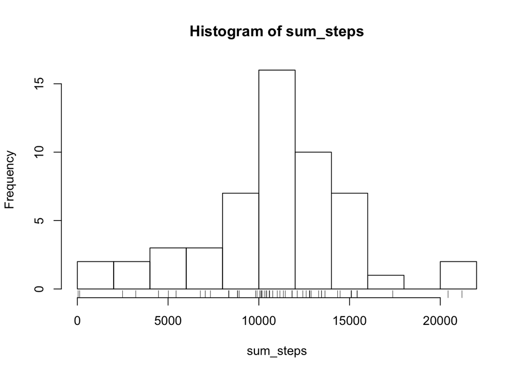

```r
hist(sum_steps, breaks = 10)
rug(sum_steps)
```

```r
dev.copy(png,file="steps_hist.png",width=480,height=480)
```

```r
dev.off()
```

Impute missing data

```r
mean_steps <- tapply(raw_data$steps, raw_data$date, mean)
mean_steps
```

```
## 2012-10-01 2012-10-02 2012-10-03 2012-10-04 2012-10-05 2012-10-06
##         NA  0.4375000 39.4166667 42.0694444 46.1597222 53.5416667
## 2012-10-07 2012-10-08 2012-10-09 2012-10-10 2012-10-11 2012-10-12
## 38.2465278         NA 44.4826389 34.3750000 35.7777778 60.3541667
## 2012-10-13 2012-10-14 2012-10-15 2012-10-16 2012-10-17 2012-10-18
## 43.1458333 52.4236111 35.2048611 52.3750000 46.7083333 34.9166667
## 2012-10-19 2012-10-20 2012-10-21 2012-10-22 2012-10-23 2012-10-24
## 41.0729167 36.0937500 30.6284722 46.7361111 30.9652778 29.0104167
## 2012-10-25 2012-10-26 2012-10-27 2012-10-28 2012-10-29 2012-10-30
##  8.6527778 23.5347222 35.1354167 39.7847222 17.4236111 34.0937500
## 2012-10-31 2012-11-01 2012-11-02 2012-11-03 2012-11-04 2012-11-05
## 53.5208333         NA 36.8055556 36.7048611         NA 36.2465278
## 2012-11-06 2012-11-07 2012-11-08 2012-11-09 2012-11-10 2012-11-11
## 28.9375000 44.7326389 11.1770833         NA         NA 43.7777778
## 2012-11-12 2012-11-13 2012-11-14 2012-11-15 2012-11-16 2012-11-17
## 37.3784722 25.4722222         NA  0.1423611 18.8923611 49.7881944
## 2012-11-18 2012-11-19 2012-11-20 2012-11-21 2012-11-22 2012-11-23
## 52.4652778 30.6979167 15.5277778 44.3993056 70.9270833 73.5902778
## 2012-11-24 2012-11-25 2012-11-26 2012-11-27 2012-11-28 2012-11-29
## 50.2708333 41.0902778 38.7569444 47.3819444 35.3576389 24.4687500
## 2012-11-30
##         NA
```

```r
median_steps <- tapply(raw_data$steps, raw_data$date, median)
head(median_steps)
```

```
## 2012-10-01 2012-10-02 2012-10-03 2012-10-04 2012-10-05 2012-10-06
##         NA          0          0          0          0          0
```

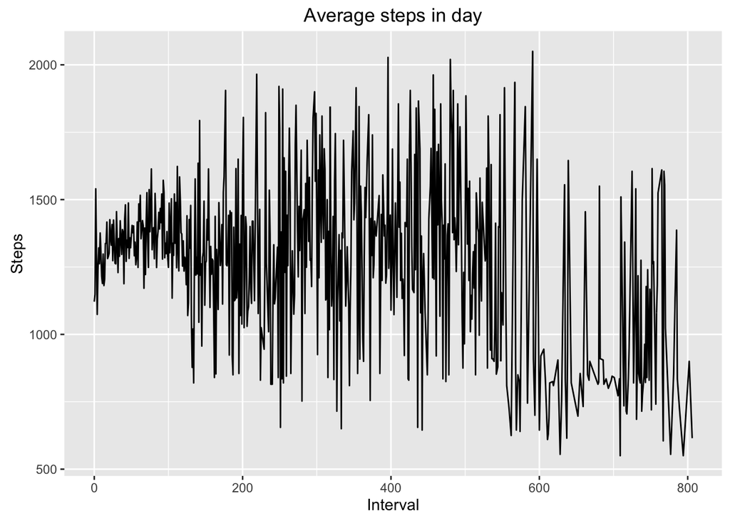

```r
time_series_array <- tapply(raw_data$interval, raw_data$steps, mean)

interval <- row.names(time_series_array)
row.names(time_series_array) <- NULL
time_series_df <- data.frame(interval, time_series_array)
names(time_series_df) <- c("Interval", "Steps")

time_series_df$Steps <- as.numeric(time_series_df$Steps)
time_series_df$Interval <- as.numeric(as.character(time_series_df$Interval))

ggplot(time_series_df, aes(Interval, Steps)) + geom_line() + ggtitle("Average steps in day")
```

```r
dev.copy(png,file="time_series.png",width=480,height=480)
```

```r
dev.off()
```

```r
time_series_df[which.max(time_series_df$Steps),]
```

```
##     Interval Steps
## 517      591  2050
```

Code to describe and show a strategy for imputing missing data

1. Calculate and report the total number of missing values in the dataset (i.e. the total number of rows with 𝙽𝙰s)

```r
summary(raw_data)
```

```
##      steps                date          interval
##  Min.   :  0.00   2012-10-01:  288   Min.   :   0.0
##  1st Qu.:  0.00   2012-10-02:  288   1st Qu.: 588.8
##  Median :  0.00   2012-10-03:  288   Median :1177.5
##  Mean   : 37.38   2012-10-04:  288   Mean   :1177.5
##  3rd Qu.: 12.00   2012-10-05:  288   3rd Qu.:1766.2
##  Max.   :806.00   2012-10-06:  288   Max.   :2355.0
##  NA's   :2304     (Other)   :15840
```

Number of rows with missing values is 2304.

2. Devise a strategy for filling in all of the missing values in the dataset. The strategy does not need to be sophisticated. For example, you could use the mean/median for that day, or the mean for that 5-minute interval, etc.

```r
reshape_data <- reshape(raw_data, timevar = "interval", times = unique(raw_data$interval), direction = "wide", idvar = "date")
to_impute_data <- reshape_data[,-1]
imputed <- impute.knn(as.matrix(to_impute_data))
```

3. Create a new dataset that is equal to the original dataset but with the missing data filled in.

```r
impute_data <- reshape_data
impute_data[1:61,2:289] <- imputed$data
long_data <- reshape(impute_data, varying = names(impute_data)[-1], direction = "long", idvar = "date", sep = "." )
orig_data_imputed <- arrange(long_data, date)
names(orig_data_imputed) <- c("date", "interval", "steps")
```

Histogram of the total number of steps taken each day after missing values are imputed

```r
i_sum_steps <- tapply(orig_data_imputed$steps, orig_data_imputed$date, sum)
head(i_sum_steps)
```

```
## 2012-10-01 2012-10-02 2012-10-03 2012-10-04 2012-10-05 2012-10-06
##   10766.19     126.00   11352.00   12116.00   13294.00   15420.00
```

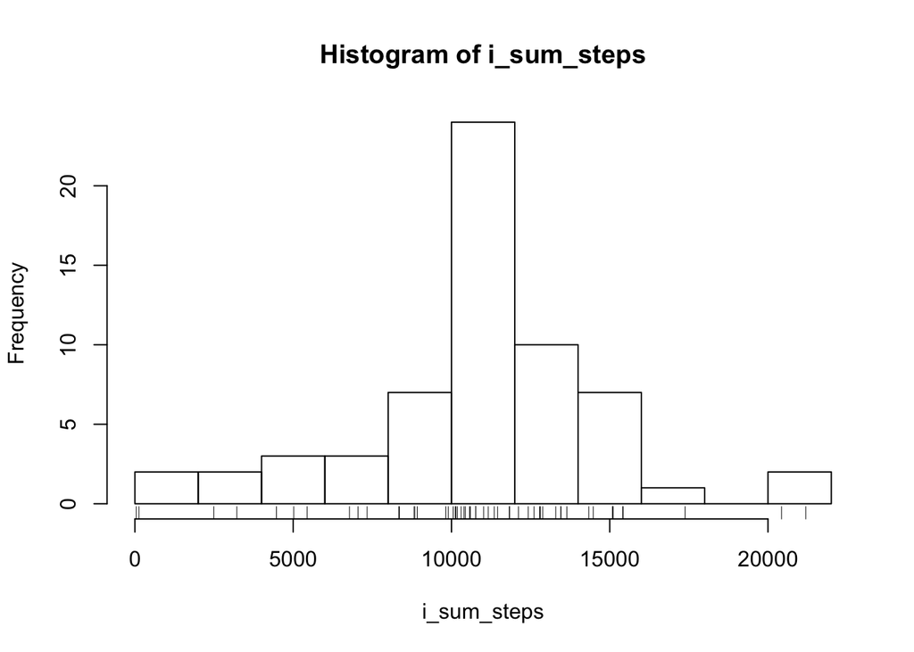

```r
hist(i_sum_steps, breaks = 10)
rug(i_sum_steps)
```

```r
dev.copy(png,file="imputed_steps_hist.png",width=480,height=480)
```

```r
dev.off()
```

```r
i_mean_steps <- tapply(orig_data_imputed$steps, orig_data_imputed$date, mean)
i_mean_steps
```

```
## 2012-10-01 2012-10-02 2012-10-03 2012-10-04 2012-10-05 2012-10-06
## 37.3825996  0.4375000 39.4166667 42.0694444 46.1597222 53.5416667
## 2012-10-07 2012-10-08 2012-10-09 2012-10-10 2012-10-11 2012-10-12
## 38.2465278 37.3825996 44.4826389 34.3750000 35.7777778 60.3541667
## 2012-10-13 2012-10-14 2012-10-15 2012-10-16 2012-10-17 2012-10-18
## 43.1458333 52.4236111 35.2048611 52.3750000 46.7083333 34.9166667
## 2012-10-19 2012-10-20 2012-10-21 2012-10-22 2012-10-23 2012-10-24
## 41.0729167 36.0937500 30.6284722 46.7361111 30.9652778 29.0104167
## 2012-10-25 2012-10-26 2012-10-27 2012-10-28 2012-10-29 2012-10-30
##  8.6527778 23.5347222 35.1354167 39.7847222 17.4236111 34.0937500
## 2012-10-31 2012-11-01 2012-11-02 2012-11-03 2012-11-04 2012-11-05
## 53.5208333 37.3825996 36.8055556 36.7048611 37.3825996 36.2465278
## 2012-11-06 2012-11-07 2012-11-08 2012-11-09 2012-11-10 2012-11-11
## 28.9375000 44.7326389 11.1770833 37.3825996 37.3825996 43.7777778
## 2012-11-12 2012-11-13 2012-11-14 2012-11-15 2012-11-16 2012-11-17
## 37.3784722 25.4722222 37.3825996  0.1423611 18.8923611 49.7881944
## 2012-11-18 2012-11-19 2012-11-20 2012-11-21 2012-11-22 2012-11-23
## 52.4652778 30.6979167 15.5277778 44.3993056 70.9270833 73.5902778
## 2012-11-24 2012-11-25 2012-11-26 2012-11-27 2012-11-28 2012-11-29
## 50.2708333 41.0902778 38.7569444 47.3819444 35.3576389 24.4687500
## 2012-11-30
## 37.3825996
```

```r
mean_steps
```

```
## 2012-10-01 2012-10-02 2012-10-03 2012-10-04 2012-10-05 2012-10-06
##         NA  0.4375000 39.4166667 42.0694444 46.1597222 53.5416667
## 2012-10-07 2012-10-08 2012-10-09 2012-10-10 2012-10-11 2012-10-12
## 38.2465278         NA 44.4826389 34.3750000 35.7777778 60.3541667
## 2012-10-13 2012-10-14 2012-10-15 2012-10-16 2012-10-17 2012-10-18
## 43.1458333 52.4236111 35.2048611 52.3750000 46.7083333 34.9166667
## 2012-10-19 2012-10-20 2012-10-21 2012-10-22 2012-10-23 2012-10-24
## 41.0729167 36.0937500 30.6284722 46.7361111 30.9652778 29.0104167
## 2012-10-25 2012-10-26 2012-10-27 2012-10-28 2012-10-29 2012-10-30
##  8.6527778 23.5347222 35.1354167 39.7847222 17.4236111 34.0937500
## 2012-10-31 2012-11-01 2012-11-02 2012-11-03 2012-11-04 2012-11-05
## 53.5208333         NA 36.8055556 36.7048611         NA 36.2465278
## 2012-11-06 2012-11-07 2012-11-08 2012-11-09 2012-11-10 2012-11-11
## 28.9375000 44.7326389 11.1770833         NA         NA 43.7777778
## 2012-11-12 2012-11-13 2012-11-14 2012-11-15 2012-11-16 2012-11-17
## 37.3784722 25.4722222         NA  0.1423611 18.8923611 49.7881944
## 2012-11-18 2012-11-19 2012-11-20 2012-11-21 2012-11-22 2012-11-23
## 52.4652778 30.6979167 15.5277778 44.3993056 70.9270833 73.5902778
## 2012-11-24 2012-11-25 2012-11-26 2012-11-27 2012-11-28 2012-11-29
## 50.2708333 41.0902778 38.7569444 47.3819444 35.3576389 24.4687500
## 2012-11-30
##         NA
```

```r
i_median_steps <- tapply(orig_data_imputed$steps, orig_data_imputed$date, median)
i_median_steps
```

```
## 2012-10-01 2012-10-02 2012-10-03 2012-10-04 2012-10-05 2012-10-06
##   34.11321    0.00000    0.00000    0.00000    0.00000    0.00000
## 2012-10-07 2012-10-08 2012-10-09 2012-10-10 2012-10-11 2012-10-12
##    0.00000   34.11321    0.00000    0.00000    0.00000    0.00000
## 2012-10-13 2012-10-14 2012-10-15 2012-10-16 2012-10-17 2012-10-18
##    0.00000    0.00000    0.00000    0.00000    0.00000    0.00000
## 2012-10-19 2012-10-20 2012-10-21 2012-10-22 2012-10-23 2012-10-24
##    0.00000    0.00000    0.00000    0.00000    0.00000    0.00000
## 2012-10-25 2012-10-26 2012-10-27 2012-10-28 2012-10-29 2012-10-30
##    0.00000    0.00000    0.00000    0.00000    0.00000    0.00000
## 2012-10-31 2012-11-01 2012-11-02 2012-11-03 2012-11-04 2012-11-05
##    0.00000   34.11321    0.00000    0.00000   34.11321    0.00000
## 2012-11-06 2012-11-07 2012-11-08 2012-11-09 2012-11-10 2012-11-11
##    0.00000    0.00000    0.00000   34.11321   34.11321    0.00000
## 2012-11-12 2012-11-13 2012-11-14 2012-11-15 2012-11-16 2012-11-17
##    0.00000    0.00000   34.11321    0.00000    0.00000    0.00000
## 2012-11-18 2012-11-19 2012-11-20 2012-11-21 2012-11-22 2012-11-23
##    0.00000    0.00000    0.00000    0.00000    0.00000    0.00000
## 2012-11-24 2012-11-25 2012-11-26 2012-11-27 2012-11-28 2012-11-29
##    0.00000    0.00000    0.00000    0.00000    0.00000    0.00000
## 2012-11-30
##   34.11321
```

```r
median_steps
```

```
## 2012-10-01 2012-10-02 2012-10-03 2012-10-04 2012-10-05 2012-10-06
##         NA          0          0          0          0          0
## 2012-10-07 2012-10-08 2012-10-09 2012-10-10 2012-10-11 2012-10-12
##          0         NA          0          0          0          0
## 2012-10-13 2012-10-14 2012-10-15 2012-10-16 2012-10-17 2012-10-18
##          0          0          0          0          0          0
## 2012-10-19 2012-10-20 2012-10-21 2012-10-22 2012-10-23 2012-10-24
##          0          0          0          0          0          0
## 2012-10-25 2012-10-26 2012-10-27 2012-10-28 2012-10-29 2012-10-30
##          0          0          0          0          0          0
## 2012-10-31 2012-11-01 2012-11-02 2012-11-03 2012-11-04 2012-11-05
##          0         NA          0          0         NA          0
## 2012-11-06 2012-11-07 2012-11-08 2012-11-09 2012-11-10 2012-11-11
##          0          0          0         NA         NA          0
## 2012-11-12 2012-11-13 2012-11-14 2012-11-15 2012-11-16 2012-11-17
##          0          0         NA          0          0          0
## 2012-11-18 2012-11-19 2012-11-20 2012-11-21 2012-11-22 2012-11-23
##          0          0          0          0          0          0
## 2012-11-24 2012-11-25 2012-11-26 2012-11-27 2012-11-28 2012-11-29
##          0          0          0          0          0          0
## 2012-11-30
##         NA
```

Panel plot comparing the average number of steps taken per 5-minute interval across weekdays and weekends

[figure not shown]

```r
weekend <- orig_data_imputed[wday(orig_data_imputed$date) == 1 | wday(orig_data_imputed$date) == 7,]
weekday <- orig_data_imputed[!(wday(orig_data_imputed$date) == 1 | wday(orig_data_imputed$date) == 7),]

ts_weekend <- tapply(weekend$interval, weekend$steps, mean)
ts_weekday <- tapply(weekday$interval, weekday$steps, mean)

interval_weekend <- row.names(ts_weekend)
row.names(ts_weekend) <- NULL
ts_df_weekend <- data.frame(interval_weekend, ts_weekend)
names(ts_df_weekend) <- c("Interval", "Steps")

interval_weekday <- row.names(ts_weekday)
row.names(ts_weekday) <- NULL
ts_df_weekday <- data.frame(interval_weekday, ts_weekday)
names(ts_df_weekday) <- c("Interval", "Steps")

ts_df_weekend$Steps <- as.numeric(ts_df_weekend$Steps)
ts_df_weekend$Interval <- as.numeric(as.character(ts_df_weekend$Interval))

ts_df_weekday$Steps <- as.numeric(ts_df_weekday$Steps)
ts_df_weekday$Interval <- as.numeric(as.character(ts_df_weekday$Interval))


weekday <- ggplot(ts_df_weekend, aes(Interval, Steps)) + geom_line() + ggtitle("Weekday")
weekend <- ggplot(ts_df_weekday, aes(Interval, Steps)) + geom_line() + ggtitle("Weekend")

grid.newpage()
pushViewport(viewport(layout = grid.layout(2, 1)))
print(weekend, vp = viewport(layout.pos.row = 1, layout.pos.col = 1))
print(weekday, vp = viewport(layout.pos.row = 2, layout.pos.col = 1))
```

```r
dev.copy(png,file="compare_time_interval.png",width=480,height=480)
```

```r
dev.off()
```

All of the R code needed to reproduce the results (numbers, plots, etc.) in the report